# Playground_#1

junjunxy1378

2025-10-29

# 1 Overview of tutorial

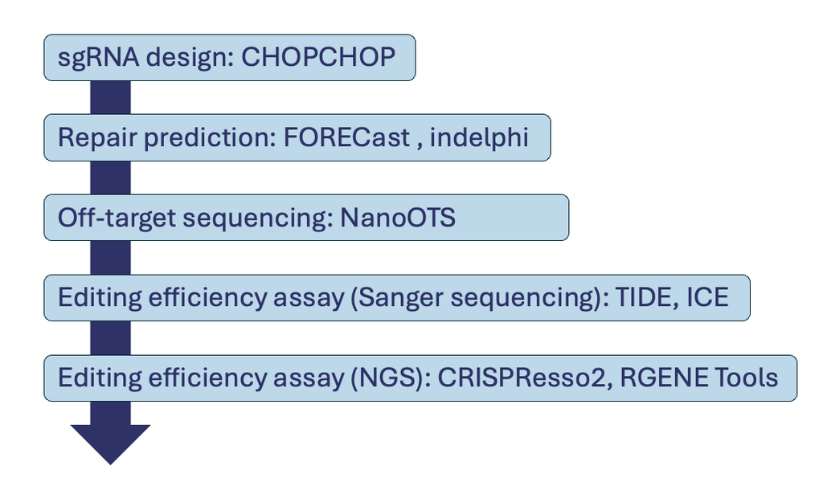

In our CRISPR/Cas9 experiments, we will perform the following steps:

- Guide RNA design
- Repair prediction
- Outcome analysis

And we will learn:

# 2 sgRNA design

[figure not shown]

Go to [CHOPCHOP](https://chopchop.cbu.uib.no/)

$Explanation$

**Target**: There are two options for submitting the target information. (1) Pasta sequence: Click “Paste Target” to input your sequence directly. (2) Gene name: Enter a gene name, ENSEMBL gene ID or NCBI RefSeq number

**In**: Selecting the species for your experiment.(If your interested species is not exist in the database, you can directly contact them to update the database)

**Using**: Default option is CRISPR/Cas9 for gene editing, but you can easily extend your experiment by selecting different Cas protein or even second generation genome editing system.

**For**: Specify the purpose of the experiment, such as Knock-out (KO), Knock-in (KI), etc.

**Options**: Specify the target region and choose whether to design primers for downstream analysis.

Example sequence - species: Homo sapiens (hg38/GRCh38)

```
AATGTCCCCCAATGGGAAGTTCATCTGGCACTGCCCACAGGTGAGGAGGTCATGATCCCCTTCTGGAGCTCCCAACGGGCCGTGGTCTGGTTCATCATCTGTAAGAATGGCTTCAAGAGGCTCGGCTGTGGTT
```

Example Ensemble ID - species: Salmo salar (Ssal_v3.1)

```
slc45a2
```

$Results$

You will find a comprehensive list of sgRNA sequences on the results page, along with other information such as strand, GC content, self-complementarity, mismatches (MM), and efficiency. The algorithm also ranks the sgRNAs based on this information.

If you click one of the sgRNA options, you can view different primers that can used to amplify the region surrounding the target.

# 3 Repair prediction

## 3.1 Using FORECast

[figure not shown]

Go to [FORECast](https://partslab.sanger.ac.uk/FORECasT)

Submit following example target DNA sequence:

```
AATGTCCCCCAATGGGAAGTTCATCTGGCACTGCCCACAGGTGAGGAGGTCATGATCCCCTTCTGGAGCTCCCAACGGGCCGTGGTCTGGTTCATCATCTGTAAGAATGGCTTCAAGAGGCTCGGCTGTGGTT
```

sgRNA:

```
CTGGAGCTCCCAACGGGCCG
```

**Index of PAM**

82

## 3.2 Using indelphi

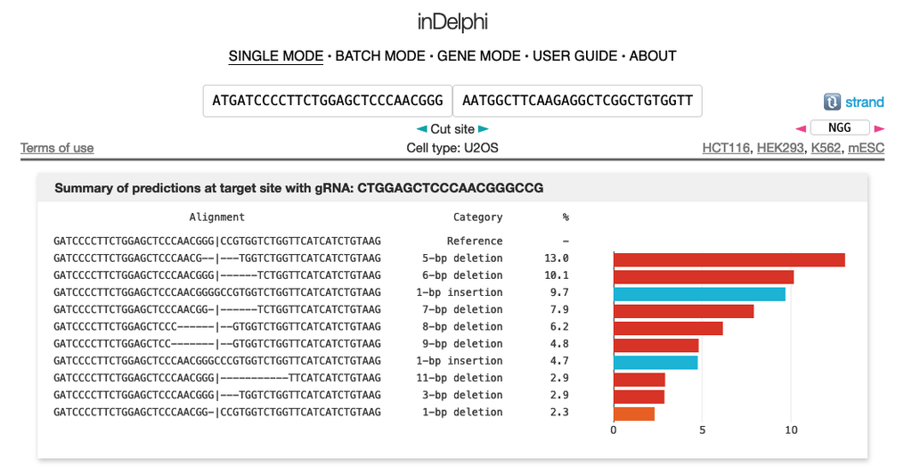

Go to [indelphi](https://indelphi.giffordlab.mit.edu/guide)

Cut site: 3bp before from PAM sequence (=Cas9 protein cleavage site)

target DNA sequence:

```
AATGTCCCCCAATGGGAAGTTCATCTGGCACTGCCCACAGGTGAGGAGGTCATGATCCCCTTCTGGAGCTCCCAACGGGCCGTGGTCTGGTTCATCATCTGTAAGAATGGCTTCAAGAGGCTCGGCTGTGGTT
```

sgRNA:

```
CTGGAGCTCCCAACGGGCCG
```

**Left & right panel**

Left panel:

AATGTCCCCCAATGGGAAGTTCATCTGGCACTGCCCACAGGTGAGGAGGTCATGATCCCCTTCTGGAGCTCCCAACGGG

Right panel:

CCGTGGTCTGGTTCATCATCTGTAAGAATGGCTTCAAGAGGCTCGGCTGTGGTT

Results

Results page visualizes the predictions for repair outcomes. In inDelphi, you can also select the cell types.

# 4 Off-target sequencing

# 5 Outcome analysis

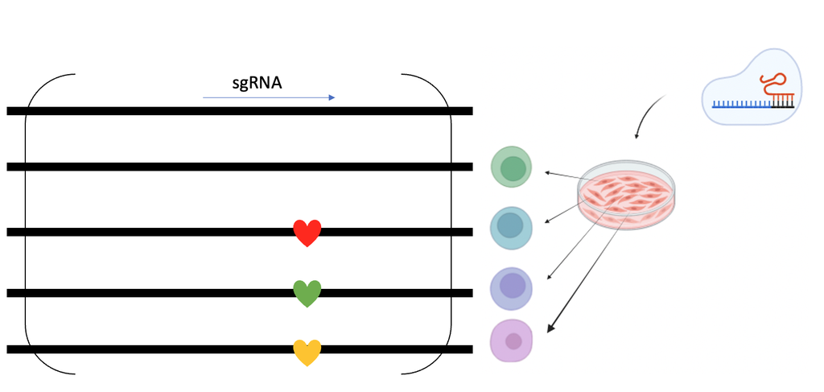

Background information:

When we conduct transfection on cells with the Cas9 protein with sgRNA, each cell will introduce the RNP complex (Cas9+sgRNA). This complex induces a double-strand break in the DNA, which the cell then attempts to repair using the Non-Homologous End Joining (NHEJ) process. As a result, each cell may end up with a different sequence in the target region after the repair process, although some cells may repair the break in a way that restores the original sequence. Consequently, when the target region is amplified, we may observe a mixture of sequences if the Cas9 has functioned effectively. To identify the mixed population of sequences, we can use either Sanger sequencing or deep sequencing (NGS).

## 5.1 Sanger sequencing

Material

Example File 1)

Control sample: [Sanger_ex1_con.ab1](https://drive.google.com/file/d/1AiI049vMI0uc3H1fm2hXWoRiPg7FkOpT/view?usp=drive_link) / Cas9 electroporated sample: [Sanger_ex1_CRISPR.ab1](https://drive.google.com/file/d/1g8B7bpDUJQYXbgbGMN_7fWZy5HGoJz5M/view?usp=drive_link)

sgRNA:

```
TGTATGAGTCGAAGATCTCC
```

Example File 2)

Control sample: [Sanger_ex2_con.ab1](https://drive.google.com/file/d/1nBu-F8fP3gsUXVvF-zOWDf9rzPVZDLKI/view?usp=drive_link) / Cas9 electroporated sample: [Sanger_ex2_CRISPR.ab1](https://drive.google.com/file/d/1TW5GlA6xGBE6Ag3gU2E98WdA-PgLAyRj/view?usp=drive_link)

sgRNA:

```
GGAAGTATACACGCTATTGT
```

TIDE

ICE analysis

Upload the control and experiment files into the appropriate categories and include the provided sgRNA information.

Results

The algorithm will decompose the trace of sequencing Chromatogram and calculate both the rage and frequency of the insertion-deletion (indel) events.

## 5.2 NGS based method

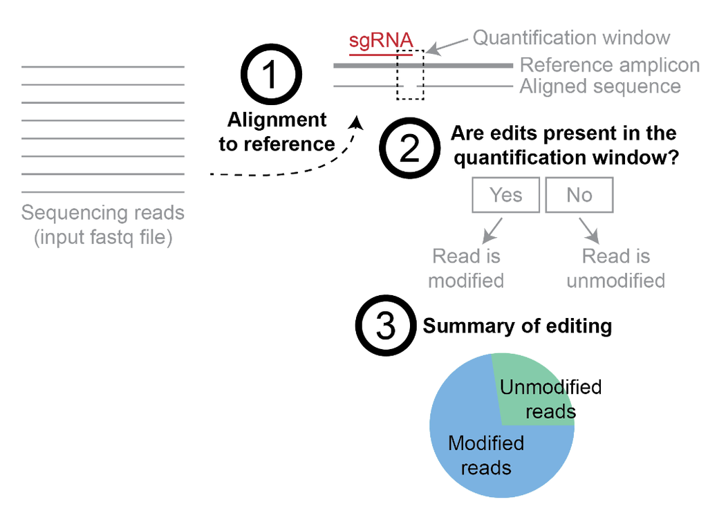

Pipeline steps:

1. NGS sequencing reads will align to the reference
2. Analyze the sequence near the quantification window
3. Summarize the results of editing

Practical Material

Fastq file R1: [deep_ex1_r1.fastq.gz](https://drive.google.com/file/d/1eAHJV7f7l33wSvzJXjkVehD5cWITRXn4/view?usp=drive_link) / Fastq file R2: [deep_ex1_r2.fastq.gz](https://drive.google.com/file/d/1VAXP7J3V9RoJSXLxHI5I0lhIjxy9OgIe/view?usp=drive_link)

Amplicon sequence (reference for alignment ):

```
AATGTCCCCCAATGGGAAGTTCATCTGGCACTGCCCACAGGTGAGGAGGTCATGATCCCCTTCTGGAGCTCCCAACGGGCCGTGGTCTGGTTCATCATCTGTAAGAATGGCTTCAAGAGGCTCGGCTGTGGTT
```

sgRNA:

```
CTGGAGCTCCCAACGGGCCG
```

Upload the reads files and amplicon, sgRNA information.

# 6 Quiz

## 6.1 Quiz.#1

Please suggest the top three sgRNA for knock-out the following gene in humans.

gene:

[output not shown]

## 6.2 Quiz.#2

To target the previously mentioned gene, we selected the following sgRNA:

```
ATAGTCCAGGAGGCAGCCGA
```

In the repair prediction using indelphi, what were the top two most abundant repair outcomes and their respective percentage?

*The sgRNA binds to the negative strand of the gene, red color in previous gene information. And following information is reverse complement of the gene:

[output not shown]

## 6.3 Quiz.#3

To knock out the previously mentioned gene, cells were transfected with Cas9 and sgRNA

```
ATAGTCCAGGAGGCAGCCGA
```

Genomic DNA was then extracted from the transfected cells and amplified using the following primer pairs:

```
Forward primer: CTGACGTGCCTCTCCCTCCC
Reverse primer: CCTTATCTCCCCTCCCCGTA
```

The amplicon was subjected to paired-end sequencing and the results are as follows:

Can you determine the editing efficiency of this sgRNA?

# 7 Reference

CRISPResso2